# What is Scikit-Learn

Collection of machine learning algorithms and tools in Python.

## Benefits and drawbacks of scikit-learn

### Benefits:

- **Consistent interface** to machine learning models
- Provides many **tuning parameters** but with **sensible defaults**
- Exceptional **documentation**
- Rich set of functionality for **companion tasks**
- **Active community** for development and support

### Potential drawbacks:

- Harder (than R) to **get started with machine learning**
- Less emphasis (than R) on **model interpretability**

## Other Important Tools of Machine Learning

### Scientific Computing

#### NumPy

- Provides fundamental data structures used by scikit-learn, particularly multi-dimensional arrays.
- Typically, data that is input to scikit-learn will be in the form of a NumPy array.
- Example import: import numpyas np
- http://www.numpy.org/

#### SciPy Library

- Provides a variety of useful scientific computing tools, including statistical distributions, optimization of functions, linear algebra, and a variety of specialized mathematical functions.
- With scikit-learn, it provides support for sparse matrices, a way to store large tables that consist mostly of zeros.
- Example import: import scipyas sp
- http://www.scipy.org/

### Data Manipulation and Analysis

#### Pandas:

- Provides key data structures like DataFrame
- Also, support for reading/writing data in different formats
- Example import: import pandas as pd
- http://pandas.pydata.org/

### Plotting libraries

#### matplotlib

```python
%matplotlib inline
import warnings
warnings.filterwarnings('ignore')

import numpy as np
import matplotlib.pyplot as plt

# use seaborn for plot defaults
# this can be safely commented out
import seaborn; seaborn.set()
```

# Getting started in scikit-learn

## scikit-learn Datasets

- Scikit-learn contains a package called **sklearn.dataset**.
- This package has several *"toy datasets"*, which are a great way to get acquainted with handling data and feed them to different ML algorithms.
- It also has generators of *random samples*, capable of constructing datasets of arbitrary complexity and size.
- There are more advanced capabilities that can help you fetch *real datasets* used in real world problems.

### Example: iris dataset

[figure not shown]

- 50 samples of 3 different species of iris (150 samples total)
- Measurements: sepal length, sepal width, petal length, petal width

### Machine learning on the iris dataset

- Framed as a **supervised learning** problem: Predict the species of an iris using the measurements
- Famous dataset for machine learning because prediction is **easy**
- Learn more about the iris dataset: [UCI Machine Learning Repository](http://archive.ics.uci.edu/ml/datasets/Iris)

### Loading the iris dataset into scikit-learn

```python
# import load_iris function from datasets module
from sklearn.datasets import load_iris
```

```python
# save "bunch" object containing iris dataset and its attributes
iris = load_iris()
type(iris)
```

```
sklearn.utils.Bunch
```

```python
# print the names of the four features
print(iris.feature_names)
```

```
['sepal length (cm)', 'sepal width (cm)', 'petal length (cm)', 'petal width (cm)']
```

```python
# print the encoding scheme for species: 0 = setosa, 1 = versicolor, 2 = virginica
print(iris.target_names)
```

```
['setosa' 'versicolor' 'virginica']
```

### How data is represented in scikit-learn

1. Features and target are **separate objects**
2. Features and target should be **numeric**
3. Features and target should be **NumPy arrays**
4. Features and target should have **specific shapes**

```python
# check the types of the features and target
print(type(iris.data))
print(type(iris.target))
```

```
<class 'numpy.ndarray'>
<class 'numpy.ndarray'>
```

```python
# check the shape of the features (first dimension = number of observations, second dimensions = number of features)
print(iris.data.shape)
```

```
(150, 4)
```

```python
# check the shape of the response (single dimension matching the number of observations)
print(iris.target.shape)
```

```
(150,)
```

```python
# print the iris data
print(iris.data[:20])
```

```
[[5.1 3.5 1.4 0.2]
 [4.9 3.  1.4 0.2]
 [4.7 3.2 1.3 0.2]
 [4.6 3.1 1.5 0.2]
 [5.  3.6 1.4 0.2]
 [5.4 3.9 1.7 0.4]
 [4.6 3.4 1.4 0.3]
 [5.  3.4 1.5 0.2]
 [4.4 2.9 1.4 0.2]
 [4.9 3.1 1.5 0.1]
 [5.4 3.7 1.5 0.2]
 [4.8 3.4 1.6 0.2]
 [4.8 3.  1.4 0.1]
 [4.3 3.  1.1 0.1]
 [5.8 4.  1.2 0.2]
 [5.7 4.4 1.5 0.4]
 [5.4 3.9 1.3 0.4]
 [5.1 3.5 1.4 0.3]
 [5.7 3.8 1.7 0.3]
 [5.1 3.8 1.5 0.3]]
```

```python
# print integers representing the species of each observation
print(iris.target)
```

```
[0 0 0 0 0 0 0 0 0 0 0 0 0 0 0 0 0 0 0 0 0 0 0 0 0 0 0 0 0 0 0 0 0 0 0 0 0
 0 0 0 0 0 0 0 0 0 0 0 0 0 1 1 1 1 1 1 1 1 1 1 1 1 1 1 1 1 1 1 1 1 1 1 1 1
 1 1 1 1 1 1 1 1 1 1 1 1 1 1 1 1 1 1 1 1 1 1 1 1 1 1 2 2 2 2 2 2 2 2 2 2 2
 2 2 2 2 2 2 2 2 2 2 2 2 2 2 2 2 2 2 2 2 2 2 2 2 2 2 2 2 2 2 2 2 2 2 2 2 2
 2 2]
```

```python
# store feature matrix in "X_iris"
X_iris = iris.data

# store response vector in "y_iris"
y_iris = iris.target
```

### A Deeper look at your data

use pandas to look at your data easly

```python
import numpy as np
import pandas as pd
# np.c_ is the numpy concatenate function
# which is used to concat iris['data'] and iris['target'] arrays
# for pandas column argument: concat iris['feature_names'] list
# and string list (in this case one string); you can make this anything you'd like..
# the original dataset would probably call this ['Species']
padnas_iris_dataset = pd.DataFrame(data= np.c_[iris['data'], iris['target']],
                     columns= iris['feature_names'] + ['target'])
```

```python
padnas_iris_dataset.head()
```

|  | sepal length (cm) | sepal width (cm) | petal length (cm) | petal width (cm) | target |
| --- | --- | --- | --- | --- | --- |
| 0 | 5.1 | 3.5 | 1.4 | 0.2 | 0.0 |
| 1 | 4.9 | 3.0 | 1.4 | 0.2 | 0.0 |
| 2 | 4.7 | 3.2 | 1.3 | 0.2 | 0.0 |
| 3 | 4.6 | 3.1 | 1.5 | 0.2 | 0.0 |
| 4 | 5.0 | 3.6 | 1.4 | 0.2 | 0.0 |

With this target array in mind, we can use Seaborn to conveniently visualize the data:

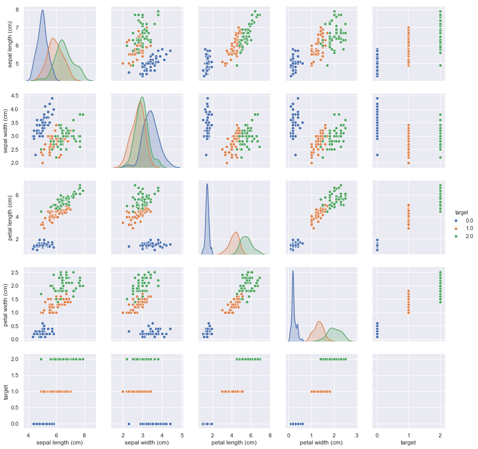

```python
import seaborn as sns; sns.set()
sns.pairplot(padnas_iris_dataset,hue ='target', height=2.5);
# the diagonal shows univariate distribution of the data
```

## The Scikit-learn Estimator Object

Every algorithm is exposed in scikit-learn via an ''Estimator'' object. For instance a linear regression is implemented as so:

```python
from sklearn.linear_model import LinearRegression
```

**Estimator parameters**: All the parameters of an estimator can be set when it is instantiated, and have suitable default values:

```python
model = LinearRegression(normalize=True)
print(model.normalize)
```

```
True
```

```python
print(model)
```

```
LinearRegression(copy_X=True, fit_intercept=True, n_jobs=None, normalize=True)
```

**Estimated Model parameters**: When data is *fit* with an estimator, parameters are estimated from the data at hand. All the estimated parameters are attributes of the estimator object ending by an *underscore* **_**

```python
help('sklearn.linear_model.LinearRegression')
```

[output not shown]

[output cut: 98 more lines]

[output not shown]

# Example 1: a classifcation problem

## scikit-learn 4-step modeling pattern (very simple API)

**Step 1:** Import your model class

```python
from sklearn.linear_model import LogisticRegression
```

**Step 2:** Instantiate an object and set the parameters

```python
lr = LogisticRegression()
```

**Step 3:** Fit the model with data (aka "model training")

```python
lr.fit(X_iris, y_iris)
```

```
LogisticRegression(C=1.0, class_weight=None, dual=False, fit_intercept=True,
          intercept_scaling=1, max_iter=100, multi_class='warn',
          n_jobs=None, penalty='l2', random_state=None, solver='warn',
          tol=0.0001, verbose=0, warm_start=False)
```

4) Apply / evaluate

```python
print(lr.predict(X_iris))
print(y_iris)
```

```
[0 0 0 0 0 0 0 0 0 0 0 0 0 0 0 0 0 0 0 0 0 0 0 0 0 0 0 0 0 0 0 0 0 0 0 0 0
 0 0 0 0 0 0 0 0 0 0 0 0 0 1 1 1 1 1 1 1 1 1 1 1 1 1 1 1 1 2 1 1 1 2 1 1 1
 1 1 1 1 1 1 1 1 1 2 2 2 1 1 1 1 1 1 1 1 1 1 1 1 1 1 2 2 2 2 2 2 2 2 2 2 2
 2 2 2 2 2 2 2 2 2 2 2 2 2 2 2 2 2 2 1 2 2 2 2 2 2 2 2 2 2 2 2 2 2 2 2 2 2
 2 2]
[0 0 0 0 0 0 0 0 0 0 0 0 0 0 0 0 0 0 0 0 0 0 0 0 0 0 0 0 0 0 0 0 0 0 0 0 0
 0 0 0 0 0 0 0 0 0 0 0 0 0 1 1 1 1 1 1 1 1 1 1 1 1 1 1 1 1 1 1 1 1 1 1 1 1
 1 1 1 1 1 1 1 1 1 1 1 1 1 1 1 1 1 1 1 1 1 1 1 1 1 1 2 2 2 2 2 2 2 2 2 2 2
 2 2 2 2 2 2 2 2 2 2 2 2 2 2 2 2 2 2 2 2 2 2 2 2 2 2 2 2 2 2 2 2 2 2 2 2 2
 2 2]
```

```python
lr.score(X_iris, y_iris)
```

```
0.96
```

#### But!!

We would like to evaluate the model on data it has not seen before, and so we will split the data into a training set and a testing set. This could be done by hand, but it is more convenient to use the train_test_split utility function:

```python
from sklearn.model_selection import train_test_split
Xtrain, Xtest, ytrain, ytest = train_test_split(X_iris, y_iris, random_state=1)
```

```python
lr.fit(Xtrain, ytrain)
y_model = lr.predict(Xtest)
```

Finally, we can use the accuracy_score utility to see the fraction of predicted labels that match their true value:

```python
from sklearn.metrics import accuracy_score
accuracy_score(ytest, y_model)
```

```
0.8421052631578947
```

# Example 2: a regression problem

Let's generate some data and use it as dataset

```python
x = np.arange(10)
y = 2 * x + 1
print(x)
print(y)
```

```
[0 1 2 3 4 5 6 7 8 9]
[ 1  3  5  7  9 11 13 15 17 19]
```

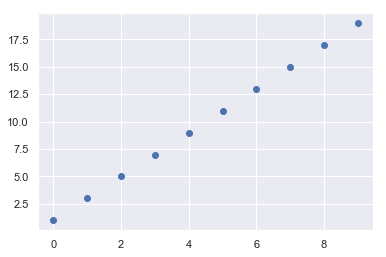

```python
plt.plot(x, y, 'o');
```

```python
# The input data for sklearn is 2D: (samples == 10 x features == 1)
X = x.reshape(-1,1)
print(X)
print(y)
```

```
[[0]
 [1]
 [2]
 [3]
 [4]
 [5]
 [6]
 [7]
 [8]
 [9]]
[ 1  3  5  7  9 11 13 15 17 19]
```

```python
model.fit(X, y)
```

```
LinearRegression(copy_X=True, fit_intercept=True, n_jobs=None, normalize=True)
```

```python
print(model.coef_)
print(model.intercept_)
```

```
[2.]
1.0
```

The model found a line with a slope 2 and intercept 1, as we'd expect.

```python
# use it to predict...
model.predict(np.array([[10]]))
```

```
array([21.])
```

## Example 3: Unsupervised learning example: Iris dimensionality

As an example of an unsupervised learning problem, let's take a look at reducing the dimensionality of the Iris data so as to more easily visualize it. Recall that the Iris data is four dimensional: there are four features recorded for each sample.

The task of dimensionality reduction is to ask whether there is a suitable lower-dimensional representation that retains the essential features of the data. Often dimensionality reduction is used as an aid to visualizing data: after all, it is much easier to plot data in two dimensions than in four dimensions or higher!

Here we will use principal component analysis (PCA: Principal Component Analysis), which is a fast linear dimensionality reduction technique. We will ask the model to return two components—that is, a two-dimensional representation of the data.

```python
from sklearn.decomposition import PCA  # 1. Choose the model class
model = PCA(n_components=2)            # 2. Instantiate the model with hyperparameters
model.fit(X_iris)                      # 3. Fit to data. Notice y is not specified!
X_2D = model.transform(X_iris)         # 4. Transform the data to two dimensions
```

Now let's plot the results. A quick way to do this is to insert the results into the original Iris DataFrame, and use Seaborn's lmplot to show the results:

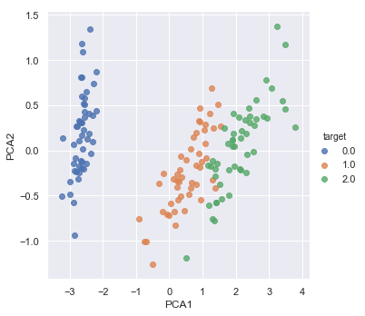

```python
padnas_iris_dataset['PCA1'] = X_2D[:, 0]
padnas_iris_dataset['PCA2'] = X_2D[:, 1]
sns.lmplot("PCA1", "PCA2", hue='target', data=padnas_iris_dataset, fit_reg=False);
```

We see that in the two-dimensional representation, the species are fairly well separated, even though the PCA algorithm had no knowledge of the species labels! This indicates to us that a relatively straightforward classification will probably be effective on the dataset, as we saw before.

## Example 4: Unsupervised learning: Iris clustering

Let's next look at applying clustering to the Iris data. A clustering algorithm attempts to find distinct groups of data without reference to any labels. Here we will use kmeans

We can fit the model as follows:

```python
from sklearn.cluster import KMeans     # 1. Choose the model class
model = KMeans(n_clusters=3)          # 2. Instantiate the model with hyperparameters
model.fit(X_iris)                    # 3. Fit to data. Notice y is not specified!
y_kmeans = model.predict(X_iris)        # 4. Determine cluster labels
```

As before, we will add the cluster label to the Iris DataFrame and use Seaborn to plot the results:

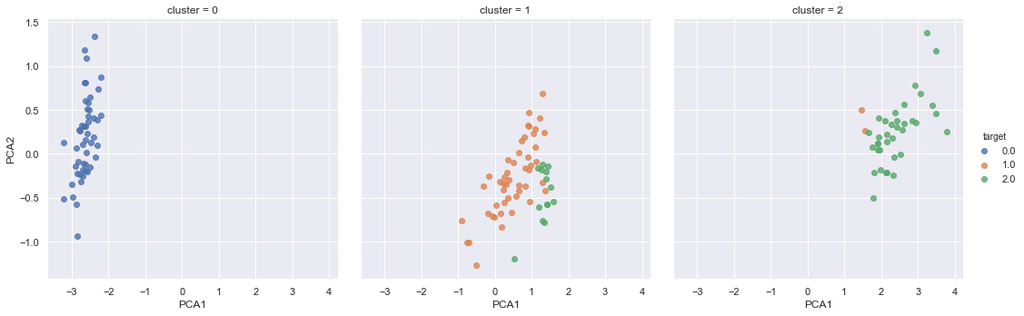

```python
padnas_iris_dataset['cluster'] = y_kmeans
sns.lmplot("PCA1", "PCA2",data=padnas_iris_dataset, hue='target',
           col='cluster', fit_reg=False)
```

By splitting the data by cluster number, we see exactly how well the kmeans algorithm has recovered the underlying label: the setosa species is separated perfectly within cluster 0, while there remains a small amount of mixing between versicolor and virginica. This means that even without an expert to tell us the species labels of the individual flowers, the measurements of these flowers are distinct enough that we could automatically identify the presence of these different groups of species with a simple clustering algorithm! This sort of algorithm might further give experts in the field clues as to the relationship between the samples they are observing.